# WQD7004 Diamond Price Prediction and Clarity Classification Project

### 5.2 Categorical Features Exploration

> In our dataset we have 3 categorical features **cut**, **color**, **clarity**, bar charts will be used to explore them

#### **cut** attribute exploration

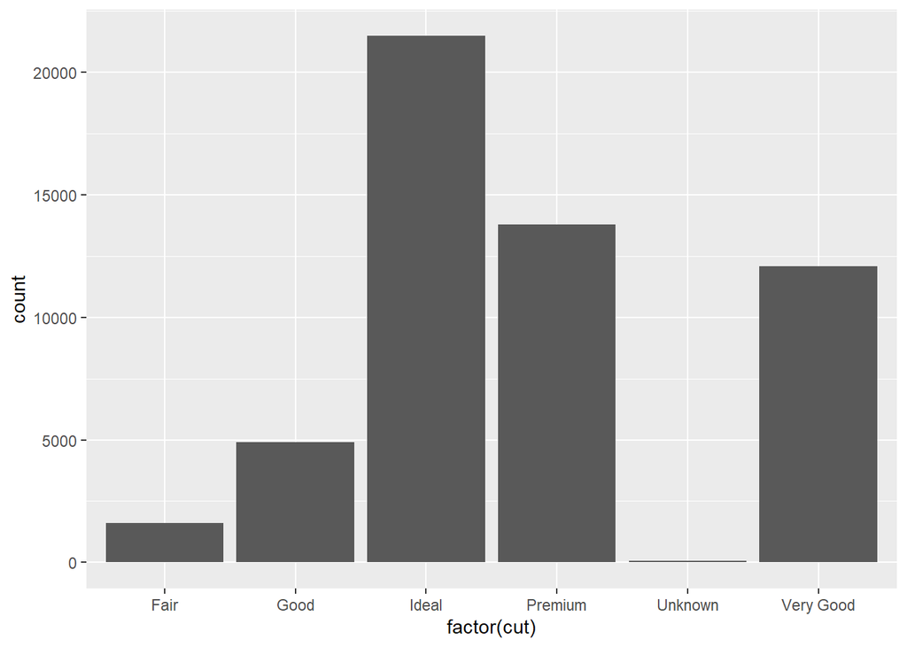

```r
library(ggplot2)
ggplot(data, aes(x = factor(cut))) +
    geom_bar()
```

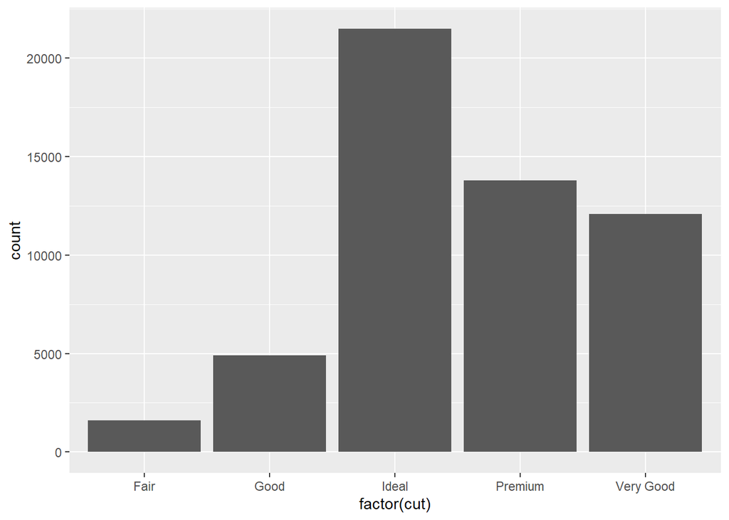

```r
data <- subset(data, cut != 'Unknown')
ggplot(data, aes(x = factor(cut))) +
    geom_bar()
```

Exploring if there are any correlation between the *cut* and the *price* of a diamond

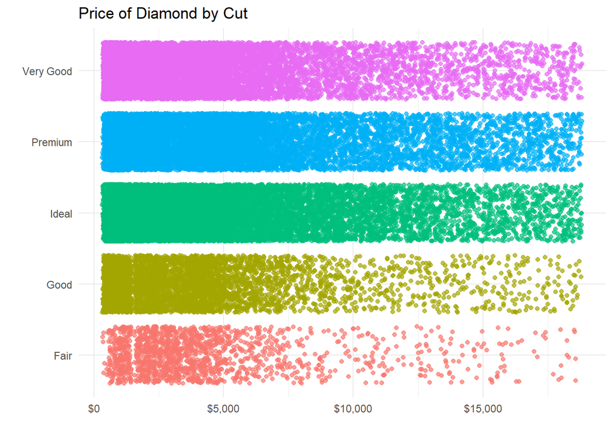

```r
library(scales)
ggplot(data,
       aes(y = factor(cut,
                      labels = c("Fair",
                                 "Good",
                                 "Ideal",
                                 "Premium",
                                 "Very Good")),
           x = price,
           color = cut)) +
  geom_jitter(alpha = 0.7,
              size = 1.5) +
  scale_x_continuous(label = dollar) +
  labs(title = "Price of Diamond by Cut",
       x = "",
       y = "") +
  theme_minimal() +
  theme(legend.position = "none")
```

From the above figure we can see that diamonds with **Premium** and **Ideal** cuts are laying the end of the price spectrum

#### **color** attribute exploration

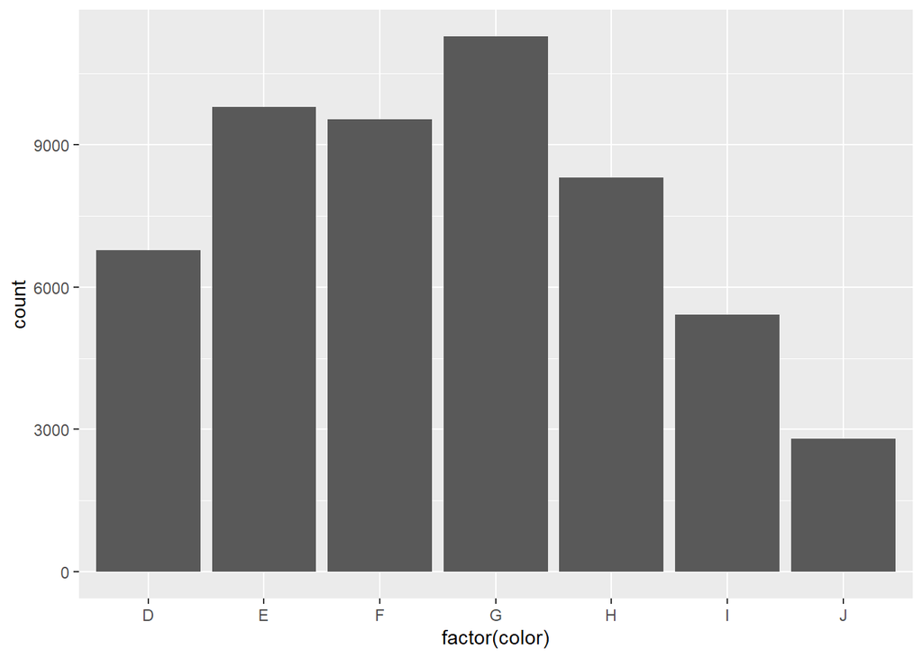

```r
ggplot(data, aes(x = factor(color))) +
    geom_bar()
```

#### **clarity** attribute exploration

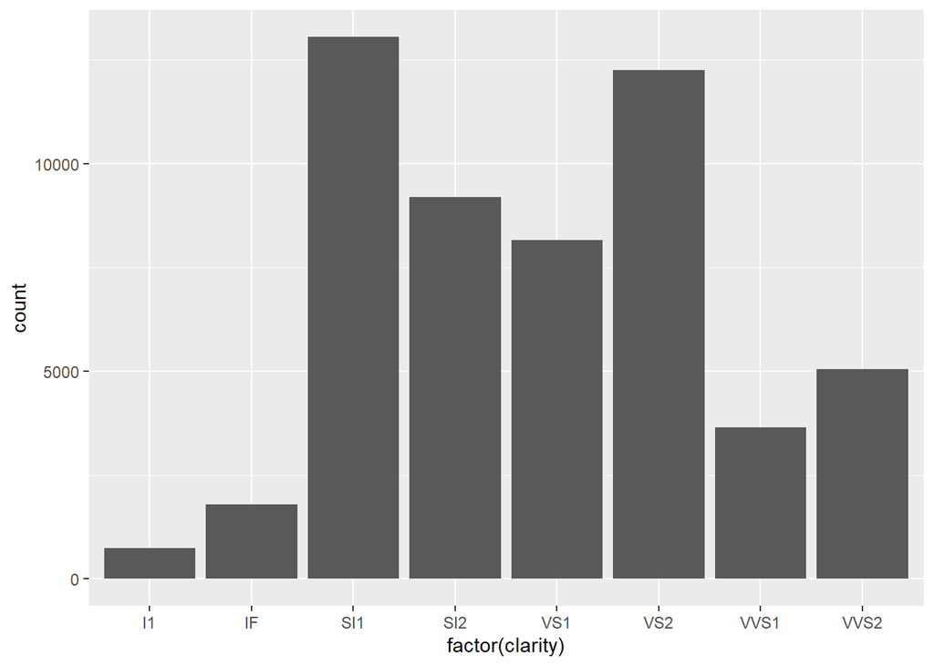

```r
ggplot(data, aes(x = factor(clarity))) +
    geom_bar()
```

```r
library(dplyr)
```

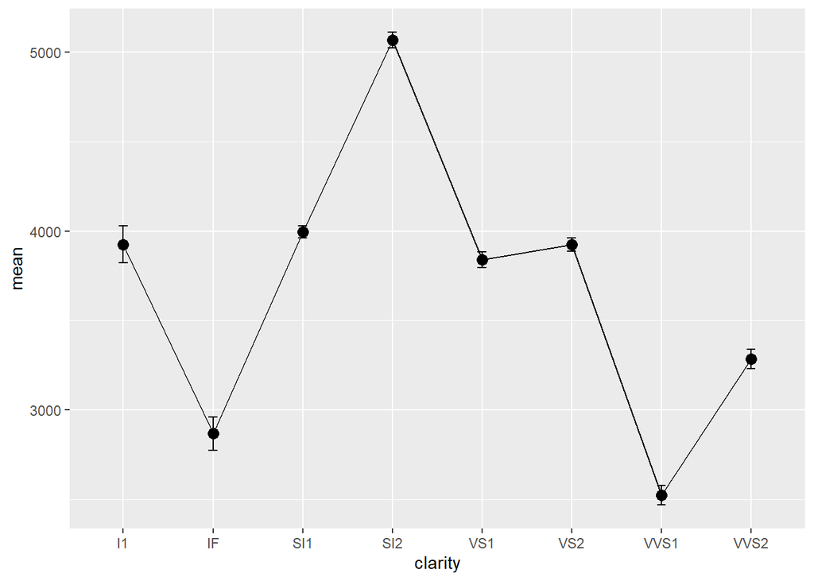

```r
plotdata <- data %>%
  group_by(clarity) %>%
  summarize(n = n(),
         mean = mean(price),
         sd = sd(price),
         se = sd / sqrt(n),
         ci = qt(0.975, df = n - 1) * sd / sqrt(n))

ggplot(plotdata,
       aes(x = clarity,
           y = mean,
           group = 1)) +
  geom_point(size = 3) +
  geom_line() +
  geom_errorbar(aes(ymin = mean - se,
                    ymax = mean + se),
                width = .1)
```

From the above plot we can see that the average price of diamonds with **Sl2** cuts are the highest while the average price of **VVS1** cuts is the lowest

### 5.3 Interval Features Exploration

```r
summary(data)
```

```
##      carat            cut               color             clarity
##  Min.   :0.2000   Length:53875       Length:53875       Length:53875
##  1st Qu.:0.4000   Class :character   Class :character   Class :character
##  Median :0.7000   Mode  :character   Mode  :character   Mode  :character
##  Mean   :0.7981
##  3rd Qu.:1.0400
##  Max.   :5.0100
##      depth           table           price             x
##  Min.   :43.00   Min.   :43.00   Min.   :  326   Min.   : 0.000
##  1st Qu.:61.00   1st Qu.:56.00   1st Qu.:  951   1st Qu.: 4.710
##  Median :61.80   Median :57.00   Median : 2401   Median : 5.700
##  Mean   :61.75   Mean   :57.46   Mean   : 3933   Mean   : 5.731
##  3rd Qu.:62.50   3rd Qu.:59.00   3rd Qu.: 5326   3rd Qu.: 6.540
##  Max.   :79.00   Max.   :95.00   Max.   :18823   Max.   :10.740
##        y                z
##  Min.   : 0.000   Min.   : 0.000
##  1st Qu.: 4.720   1st Qu.: 2.910
##  Median : 5.710   Median : 3.530
##  Mean   : 5.735   Mean   : 3.539
##  3rd Qu.: 6.540   3rd Qu.: 4.040
##  Max.   :58.900   Max.   :31.800
```

From the above summary we can see that min value of “x”, “y”, “z” are zero this indicates that there are faulty values in data that represents dimensionless or 2-dimensional diamonds. So we need to filter out those as it clearly faulty data points.

```r
library(tidyr)
data <- filter(data, x > 0, y > 0, z > 0)
summary(data)
```

```
##      carat            cut               color             clarity
##  Min.   :0.2000   Length:53855       Length:53855       Length:53855
##  1st Qu.:0.4000   Class :character   Class :character   Class :character
##  Median :0.7000   Mode  :character   Mode  :character   Mode  :character
##  Mean   :0.7978
##  3rd Qu.:1.0400
##  Max.   :5.0100
##      depth           table           price             x
##  Min.   :43.00   Min.   :43.00   Min.   :  326   Min.   : 3.730
##  1st Qu.:61.00   1st Qu.:56.00   1st Qu.:  950   1st Qu.: 4.710
##  Median :61.80   Median :57.00   Median : 2401   Median : 5.700
##  Mean   :61.75   Mean   :57.46   Mean   : 3932   Mean   : 5.732
##  3rd Qu.:62.50   3rd Qu.:59.00   3rd Qu.: 5324   3rd Qu.: 6.540
##  Max.   :79.00   Max.   :95.00   Max.   :18823   Max.   :10.740
##        y                z
##  Min.   : 3.680   Min.   : 1.07
##  1st Qu.: 4.720   1st Qu.: 2.91
##  Median : 5.710   Median : 3.53
##  Mean   : 5.735   Mean   : 3.54
##  3rd Qu.: 6.540   3rd Qu.: 4.04
##  Max.   :58.900   Max.   :31.80
```

To explore the distribution of interval variables, histogram plots are used

```r
library("tidyr")
library("ggplot2")
drops <- c('cut', 'clarity', 'color')
hist_data = data[ , !(names(data) %in% drops)]
data_long <- hist_data %>%                          # Apply pivot_longer function
  pivot_longer(colnames(hist_data)) %>%
  as.data.frame()
head(data_long)
```

```
##    name  value
## 1 carat   0.23
## 2 depth  61.50
## 3 table  55.00
## 4 price 326.00
## 5     x   3.95
## 6     y   3.98
```

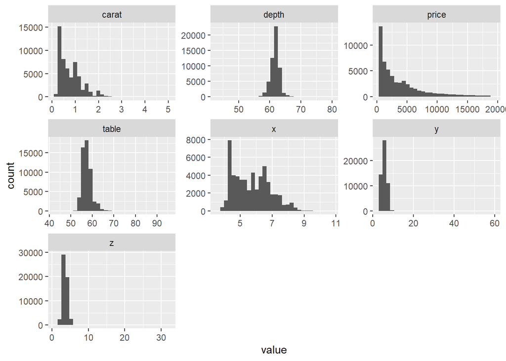

```r
ggp1 <- ggplot(data_long, aes(x = value)) +    # Draw each column as histogram
  geom_histogram() +
  facet_wrap(~ name, scales = "free")
ggp1
```

From the above histogram plots, we can see that the **price** attribute and **caret** attribute are right skewed, thus to ensure that our machine learning models are accurate and robut, data transformations will be conducted.

### 5.4 Data Transformation

```r
library(superml)
label <- LabelEncoder$new()
data$cut <- label$fit_transform(data$cut)
data$color <- label$fit_transform(data$color)
data$clarity <- label$fit_transform(data$clarity)
summary(data)
```

```
##      carat             cut           color          clarity
##  Min.   :0.2000   Min.   :0.00   Min.   :0.000   Min.   :0.000
##  1st Qu.:0.4000   1st Qu.:0.00   1st Qu.:1.000   1st Qu.:1.000
##  Median :0.7000   Median :1.00   Median :4.000   Median :2.000
##  Mean   :0.7978   Mean   :1.23   Mean   :3.174   Mean   :2.256
##  3rd Qu.:1.0400   3rd Qu.:3.00   3rd Qu.:5.000   3rd Qu.:3.000
##  Max.   :5.0100   Max.   :4.00   Max.   :6.000   Max.   :7.000
##      depth           table           price             x
##  Min.   :43.00   Min.   :43.00   Min.   :  326   Min.   : 3.730
##  1st Qu.:61.00   1st Qu.:56.00   1st Qu.:  950   1st Qu.: 4.710
##  Median :61.80   Median :57.00   Median : 2401   Median : 5.700
##  Mean   :61.75   Mean   :57.46   Mean   : 3932   Mean   : 5.732
##  3rd Qu.:62.50   3rd Qu.:59.00   3rd Qu.: 5324   3rd Qu.: 6.540
##  Max.   :79.00   Max.   :95.00   Max.   :18823   Max.   :10.740
##        y                z
##  Min.   : 3.680   Min.   : 1.07
##  1st Qu.: 4.720   1st Qu.: 2.91
##  Median : 5.710   Median : 3.53
##  Mean   : 5.735   Mean   : 3.54
##  3rd Qu.: 6.540   3rd Qu.: 4.04
##  Max.   :58.900   Max.   :31.80
```

From the above summary, we can see that all categorical attributes (**cut**, **color**, **calarity**) were encoded into numerical values, this is crucial for the robustness of our machine learning models

Since the data attributes have different scales, standardization is required to ensure that our machine learning model is not facing overfitting/underfitting issues and biases

```r
model_data = scale(data)
summary(model_data)
```

```
##      carat              cut              color            clarity
##  Min.   :-1.2618   Min.   :-0.9718   Min.   :-1.5481   Min.   :-1.2771
##  1st Qu.:-0.8397   1st Qu.:-0.9718   1st Qu.:-1.0603   1st Qu.:-0.7110
##  Median :-0.2065   Median :-0.1820   Median : 0.4029   Median :-0.1449
##  Mean   : 0.0000   Mean   : 0.0000   Mean   : 0.0000   Mean   : 0.0000
##  3rd Qu.: 0.5112   3rd Qu.: 1.3977   3rd Qu.: 0.8906   3rd Qu.: 0.4212
##  Max.   : 8.8907   Max.   : 2.1875   Max.   : 1.3783   Max.   : 2.6857
##      depth               table             price               x
##  Min.   :-13.08480   Min.   :-6.4703   Min.   :-0.9043   Min.   :-1.78846
##  1st Qu.: -0.52317   1st Qu.:-0.6526   1st Qu.:-0.7478   1st Qu.:-0.91297
##  Median :  0.03512   Median :-0.2051   Median :-0.3839   Median :-0.02854
##  Mean   :  0.00000   Mean   : 0.0000   Mean   : 0.0000   Mean   : 0.00000
##  3rd Qu.:  0.52363   3rd Qu.: 0.6900   3rd Qu.: 0.3493   3rd Qu.: 0.72189
##  Max.   : 12.03846   Max.   :16.8007   Max.   : 3.7350   Max.   : 4.47403
##        y                 z
##  Min.   :-1.8026   Min.   :-3.51634
##  1st Qu.:-0.8904   1st Qu.:-0.89714
##  Median :-0.0221   Median :-0.01458
##  Mean   : 0.0000   Mean   : 0.00000
##  3rd Qu.: 0.7059   3rd Qu.: 0.71139
##  Max.   :46.6317   Max.   :40.22715
```

Finally, the data will be split into 70% training set and 30% testing set

```r
library(caret)
set.seed(101) # Set Seed so that same sample can be reproduced

# Now Selecting 70% of data as sample from total 'n' rows of the data
Sample <- createDataPartition(data$price, p=0.7, list = FALSE)
Training_data <- data[Sample,] # Training Set
Testing_data <- data[-Sample,] # Test Set
```

# **6.Machine Learning**

### 6.1 Diamond price Prediction

The **Linear Regression** algorithm is used to predict the diamond price and to determine which attribute affects the most.

```r
#Load training and testing dataset
trainset = read.csv('data/train_set.csv')
testset = read.csv('data/test_set.csv')

#Build Training Model
model <- train(price ~ ., data = trainset,
               method = "lm",
)

model
```

```
## Linear Regression
##
## 37698 samples
##     9 predictor
##
## No pre-processing
## Resampling: Bootstrapped (25 reps)
## Summary of sample sizes: 37698, 37698, 37698, 37698, 37698, 37698, ...
## Resampling results:
##
##   RMSE       Rsquared   MAE
##   0.3767199  0.8592983  0.2139301
##
## Tuning parameter 'intercept' was held constant at a value of TRUE
```

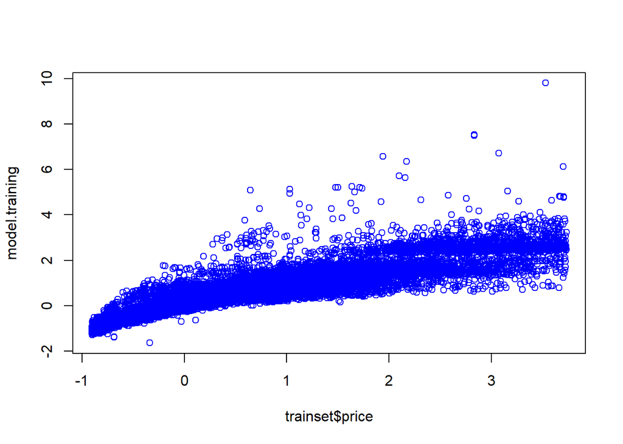

```r
# Apply model for prediction
model.training <-predict(model, trainset) # Apply model to predict the diamond pricing of the training set.
model.testing <-predict(model, testset) # Apply model to predict the diamond pricing of the testing set. predicting the test result

# Model performance
  # Scatter plot of Training set
    plot(trainset$price,model.training, col = "blue" )
```

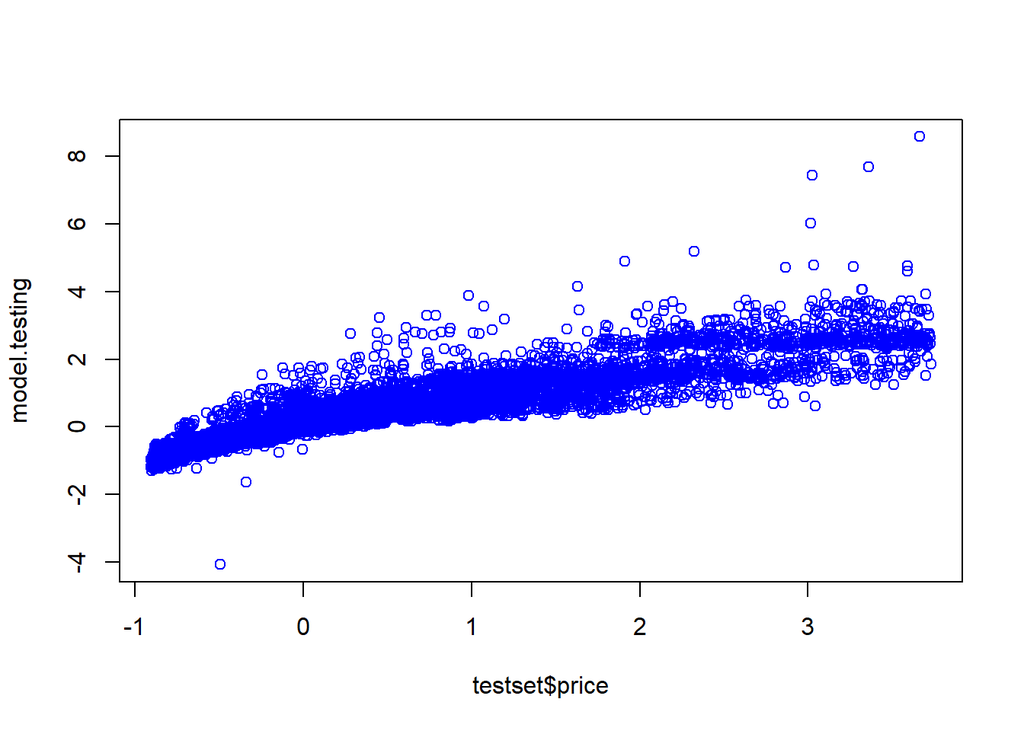

```r
  # Scatter plot of Testing set
    plot(testset$price,model.testing, col = "blue" )
```

x-axis represent the actual value and y-axis is the predicted value. The first one to predict the diamond pricing of the training set and the second one for test set. From the scatter plot above we can see that they are relatively good correlation for both training and testing set.

```r
#Model Performance Summary
    summary(model)
```

```
##
## Call:
## lm(formula = .outcome ~ ., data = dat)
##
## Residuals:
##     Min      1Q  Median      3Q     Max
## -6.2667 -0.1436 -0.0200  0.1022  2.8646
##
## Coefficients:
##              Estimate Std. Error t value Pr(>|t|)
## (Intercept)  0.001030   0.001851   0.557 0.577819
## carat        1.253218   0.009284 134.984  < 2e-16 ***
## cut         -0.026506   0.002127 -12.461  < 2e-16 ***
## color        0.043546   0.001855  23.481  < 2e-16 ***
## clarity      0.113125   0.001967  57.518  < 2e-16 ***
## depth       -0.046829   0.004844  -9.668  < 2e-16 ***
## table       -0.033693   0.002234 -15.082  < 2e-16 ***
## x           -0.239267   0.033057  -7.238 4.64e-13 ***
## y            0.029367   0.008302   3.537 0.000405 ***
## z           -0.083226   0.036766  -2.264 0.023602 *
## ---
## Signif. codes:  0 '***' 0.001 '**' 0.01 '*' 0.05 '.' 0.1 ' ' 1
##
## Residual standard error: 0.3594 on 37688 degrees of freedom
## Multiple R-squared:  0.8713, Adjusted R-squared:  0.8713
## F-statistic: 2.836e+04 on 9 and 37688 DF,  p-value: < 2.2e-16
```

From the performance summary, the variable that influence model the most is carat because the absolute value is at the most. The p value with 3 star indicates that the variables are highly significant in predicting the dependent variable.

```r
#Calculate Pearson's correlation coefficient of the actual value and predicted value.

#Pearson's correlation coefficient of Training set
 corr_training <- cor.test(trainset$price,model.training, method = "pearson")
 corr_training
```

```
##
##  Pearson's product-moment correlation
##
## data:  trainset$price and model.training
## t = 505.28, df = 37696, p-value < 2.2e-16
## alternative hypothesis: true correlation is not equal to 0
## 95 percent confidence interval:
##  0.9321486 0.9347463
## sample estimates:
##       cor
## 0.9334597
```

```r
#Pearson's correlation coefficient of Testing set
 corr_testing <- cor.test(testset$price,model.testing, method = "pearson")
 corr_testing
```

```
##
##  Pearson's product-moment correlation
##
## data:  testset$price and model.testing
## t = 340.91, df = 16155, p-value < 2.2e-16
## alternative hypothesis: true correlation is not equal to 0
## 95 percent confidence interval:
##  0.9350872 0.9388515
## sample estimates:
##       cor
## 0.9369965
```

The correlation coefficient between actual and predicted value for both training and testing set is 0.933 and 0.936 respectively, suggests a strong positive correlation. The p value for the test is smaller than 0.05, thus, the null hypothesis is rejected. We can conclude that our Linear Regression model is statistically significant.

```r
#Finding accuracy
actuals_prediction <- data.frame(cbind(Actual=testset$price, Predicted=model.testing))
correlation_accuracy <- cor(actuals_prediction)
head(actuals_prediction)
```

```
##       Actual  Predicted
## 1 -0.9043258 -1.1746243
## 2 -0.9023193 -0.9688205
## 3 -0.9015668 -1.2959646
## 4 -0.8980554 -1.1008643
## 5 -0.8980554 -1.1206293
## 6 -0.8975538 -1.0248016
```

Based on the above output, there is not much difference between the predicted and actual value which means it can predict the price quite well.

### 6.2.1 Diamond Cut Classification using Naive Bayes

```r
data_cut = read.csv('data/clean_dataset_diamond.csv')
library(superml)
label <- LabelEncoder$new()
data_cut$color <- label$fit_transform(data_cut$color)
data_cut$clarity <- label$fit_transform(data_cut$clarity)

set.seed(101)
sample <- sample.int(n = nrow(data_cut), size = floor(.7*nrow(data_cut)), replace = F)
train_data <- data_cut[sample, ]
test_data  <- data_cut[-sample, ]
```

```r
# classification
library(klaR)
library(e1071)
library(caret)
library(dplyr)

new_train_data <-dplyr::select(train_data, -cut)
x= new_train_data[,1:9]
y= as.factor(train_data$cut)

#naive bayes
model = train(x, y,'nb',preProcess = c("scale") ,trControl = trainControl(method = 'cv', number=10))
Predict <- predict(model, newdata = test_data)
test_data$cut <- as.factor( test_data$cut)
confusionMatrix(Predict, test_data$cut)
```

```
## Confusion Matrix and Statistics
##
##            Reference
## Prediction  Fair Good Ideal Premium Very Good
##   Fair       348   47    13       6         7
##   Good        64  634     5       8       130
##   Ideal       13  156  5438     989      1105
##   Premium     45  219   652    2680      1286
##   Very Good    9  438   392     398      1075
##
## Overall Statistics
##
##                Accuracy : 0.6298
##                  95% CI : (0.6223, 0.6372)
##     No Information Rate : 0.4023
##     P-Value [Acc > NIR] : < 2.2e-16
##
##                   Kappa : 0.4668
##
##  Mcnemar's Test P-Value : < 2.2e-16
##
## Statistics by Class:
##
##                      Class: Fair Class: Good Class: Ideal Class: Premium
## Sensitivity              0.72651     0.42436       0.8366         0.6567
## Specificity              0.99534     0.98588       0.7657         0.8177
## Pos Pred Value           0.82660     0.75386       0.7061         0.5490
## Neg Pred Value           0.99168     0.94385       0.8744         0.8757
## Prevalence               0.02965     0.09247       0.4023         0.2526
## Detection Rate           0.02154     0.03924       0.3366         0.1659
## Detection Prevalence     0.02606     0.05205       0.4766         0.3022
## Balanced Accuracy        0.86093     0.70512       0.8011         0.7372
##                      Class: Very Good
## Sensitivity                   0.29836
## Specificity                   0.90147
## Pos Pred Value                0.46497
## Neg Pred Value                0.81741
## Prevalence                    0.22300
## Detection Rate                0.06653
## Detection Prevalence          0.14310
## Balanced Accuracy             0.59991
```

Based on the statistics above, an accuracy of 62.98% is achieved. In terms of sensitivity, ‘Ideal class’ has the highest sensitivity and ‘Very Good’ class has the lowest sensitivity.

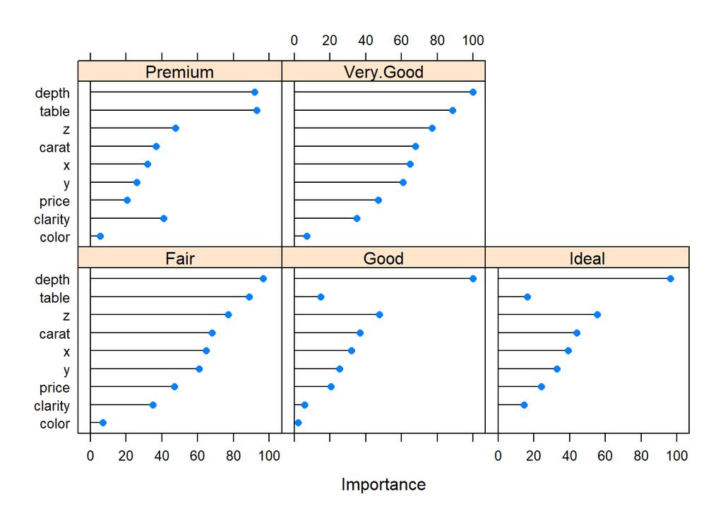

```r
X<- varImp(model)
plot(X)
```

The plot above shows that the attribute depth which represents the total depth percentage of a diamond has the highest significant value to predict the cut of the diamond.

### 6.2.2 Diamond Cut Classification using Random Forest

```r
library(caTools)
library(randomForest)
classifier_RF = randomForest(x = x, y = y, ntree = 500)
classifier_RF
```

```
##
## Call:
##  randomForest(x = x, y = y, ntree = 500)
##                Type of random forest: classification
##                      Number of trees: 500
## No. of variables tried at each split: 3
##
##         OOB estimate of  error rate: 21.39%
## Confusion matrix:
##           Fair Good Ideal Premium Very Good class.error
## Fair       990   81    10      33        16  0.12389381
## Good        95 2335    53     154       771  0.31484742
## Ideal        8   23 13785     565       602  0.07995728
## Premium      0   24  1048    7910       717  0.18445201
## Very Good    6  489  1803    1567      4613  0.45588582
```

Load RandomForest library and set the variables into the RF classifier.

```r
y_pred = predict(classifier_RF, newdata = test_data )
confusionMatrix(y_pred, test_data$cut)
```

```
## Confusion Matrix and Statistics
##
##            Reference
## Prediction  Fair Good Ideal Premium Very Good
##   Fair       422   43     6       0         5
##   Good        36 1030    16      11       176
##   Ideal        3   29  5899     439       767
##   Premium     11   63   281    3299       707
##   Very Good    7  329   298     332      1948
##
## Overall Statistics
##
##                Accuracy : 0.7797
##                  95% CI : (0.7733, 0.7861)
##     No Information Rate : 0.4023
##     P-Value [Acc > NIR] : < 2.2e-16
##
##                   Kappa : 0.6879
##
##  Mcnemar's Test P-Value : < 2.2e-16
##
## Statistics by Class:
##
##                      Class: Fair Class: Good Class: Ideal Class: Premium
## Sensitivity              0.88100     0.68942       0.9075         0.8084
## Specificity              0.99656     0.98370       0.8718         0.9121
## Pos Pred Value           0.88655     0.81166       0.8265         0.7565
## Neg Pred Value           0.99637     0.96883       0.9334         0.9337
## Prevalence               0.02965     0.09247       0.4023         0.2526
## Detection Rate           0.02612     0.06375       0.3651         0.2042
## Detection Prevalence     0.02946     0.07854       0.4417         0.2699
## Balanced Accuracy        0.93878     0.83656       0.8897         0.8602
##                      Class: Very Good
## Sensitivity                    0.5407
## Specificity                    0.9231
## Pos Pred Value                 0.6685
## Neg Pred Value                 0.8750
## Prevalence                     0.2230
## Detection Rate                 0.1206
## Detection Prevalence           0.1804
## Balanced Accuracy              0.7319
```

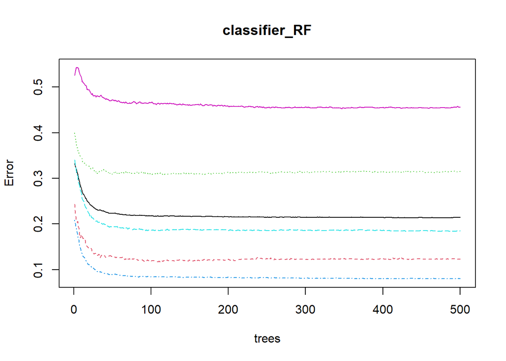

```r
plot(classifier_RF)
```

```r
importance(classifier_RF)
```

```
##         MeanDecreaseGini
## carat          1353.8477
## color           971.3938
## clarity         930.8295
## depth          6154.3184
## table          7264.2708
## price          2675.6347
## x              2896.7183
## y              2779.8443
## z              1907.4390
```

We can see that the attribute table is the most significant attribute which is then followed by attribute depth.

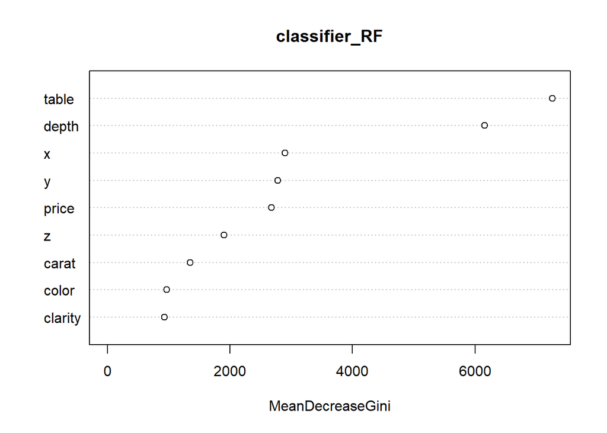

```r
varImpPlot(classifier_RF)
```

The plot shows that as the MeanDecreaseGini increases, the attribute becomes more significant and in this case, the attribute table is the most significant feature which is then followed by depth.

# **7.Conclusion**